# FlipTheFleet Test Black Box Data: Testing Time of Charging

Exploration of test data

Ben Anderson (b.anderson@soton.ac.uk, `@dataknut`)

Last run at: 2018-06-21 15:11:10

# 1 Citation

If you wish to use any of the material from this report please cite as:

- Anderson, B. (2018) FlipTheFleet Test Black Box Data: Testing Time of Charging: Exploration of test data, [Centre for Sustainability](http://www.otago.ac.nz/centre-sustainability/), University of Otago: Dunedin.

This work is (c) 2018 the University of Southampton.

# 2 About

## 2.1 Circulation

Report circulation:

- Restricted to: [NZ GREEN Grid](https://www.otago.ac.nz/centre-sustainability/research/energy/otago050285.html) project partners and contractors.

## 2.2 Purpose

This report is intended to:

- load and test preliminary ‘[black box](https://flipthefleet.org/ev-black-box/)’ EV monitoring data provided for assessment purposes by [FlipTheFleet](http://flipthefleet.org/)
- preliminary analysis of time of charging to understand impact on ‘peak’ electricity demand

[figure not shown]

The Black Box (Source: FlipTheFleet)

## 2.3 Requirements:

- test dataset stored at /Volumes/hum-csafe/Research Projects/GREEN Grid/_RAW DATA/flipTheFleet/

## 2.4 History

Generally tracked via our git.soton [repo](https://git.soton.ac.uk/ba1e12/nzGREENGrid):

- [history](https://git.soton.ac.uk/ba1e12/nzGREENGrid/commits/master)
- issues

Specific history of this code:

- https://git.soton.ac.uk/ba1e12/nzGREENGrid/tree/master/analysis/ev

## 2.5 Support

This work was supported by:

- The [University of Otago](https://www.otago.ac.nz/);
- The [University of Southampton](https://www.southampton.ac.uk/);
- The New Zealand [Ministry of Business, Innovation and Employment (MBIE)](http://www.mbie.govt.nz/) through the [NZ GREEN Grid](https://www.otago.ac.nz/centre-sustainability/research/energy/otago050285.html) project;
- [SPATIALEC](http://www.energy.soton.ac.uk/tag/spatialec/) - a [Marie Skłodowska-Curie Global Fellowship](http://ec.europa.eu/research/mariecurieactions/about-msca/actions/if/index_en.htm) based at the University of Otago’s [Centre for Sustainability](http://www.otago.ac.nz/centre-sustainability/staff/otago673896.html) (2017-2019) & the University of Southampton’s Sustainable Energy Research Group (2019-202).

We do not ‘support’ the code but if you have a problem check the issues on our [repo](https://git.soton.ac.uk/ba1e12/nzGREENGrid) and if it doesn’t already exist, open one. We might be able to fix it :-)

# 3 Load data files

## 3.1 EV test data

In this section we load and describe the data from /Volumes/hum-csafe/Research Projects/GREEN Grid/_RAW DATA/flipTheFleet/EVBlackBox export 2018-06-10-233146.csv. Note that we remove the following variables before we do so as they are potentially disclosive:

- `Reg No`
- `Latitude`
- `Longitude`
- `Course (deg)`

Create some useful derived variables.

```r
# create derived variables
ftfSafeDT <- createDerivedFtF(ftfSafeDT)
```

See [ftFBlackBoxTestDataCodebook.docx](https://www.dropbox.com/s/bfepx3sgfxek78e/ftFBlackBoxTestDataCodebook.docx?dl=0) for a full description of the data.

Check charger related variables. We think these are:

- `Charger (amps)`
- `Charger (V)`

Multiplying these two will give power in W. The following plots examine the distribution of amps, volts and the derived W.

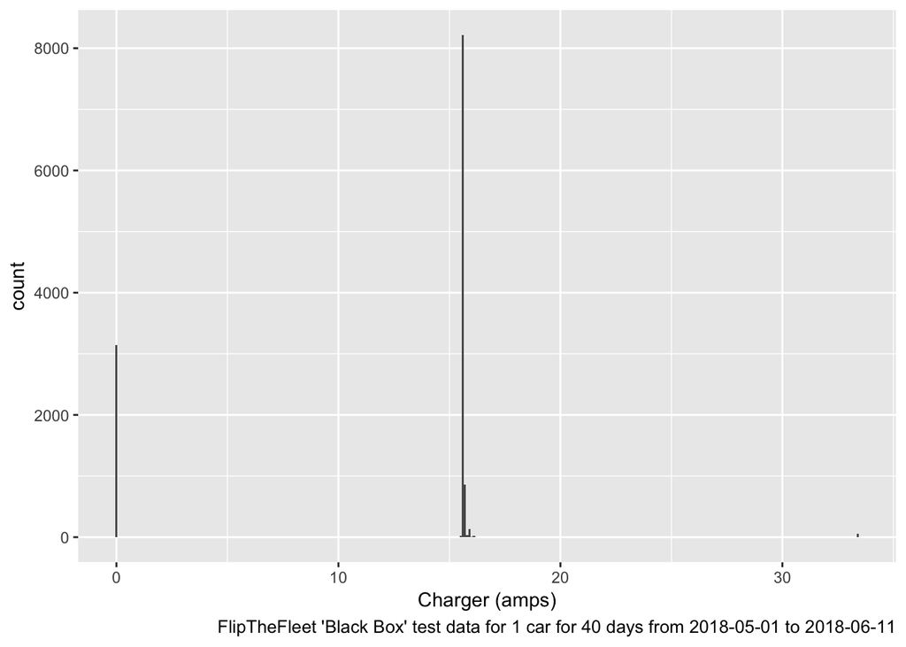

Figure 3.1: Distirbution of charger amp readings

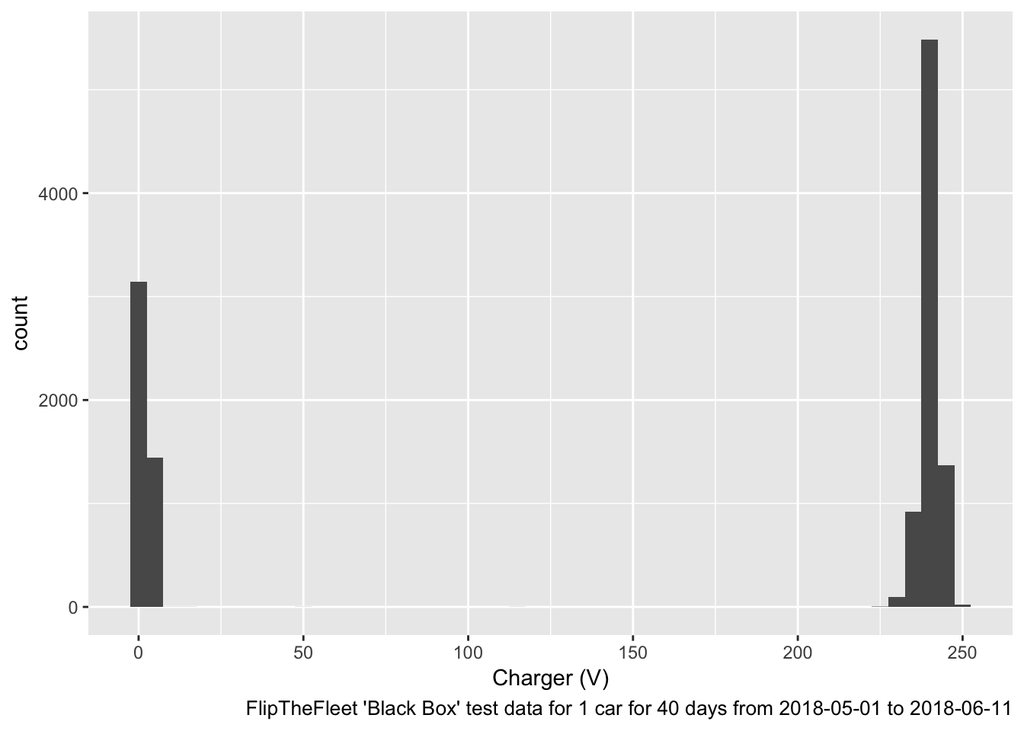

Figure 3.2: Distirbution of chargr volt readings

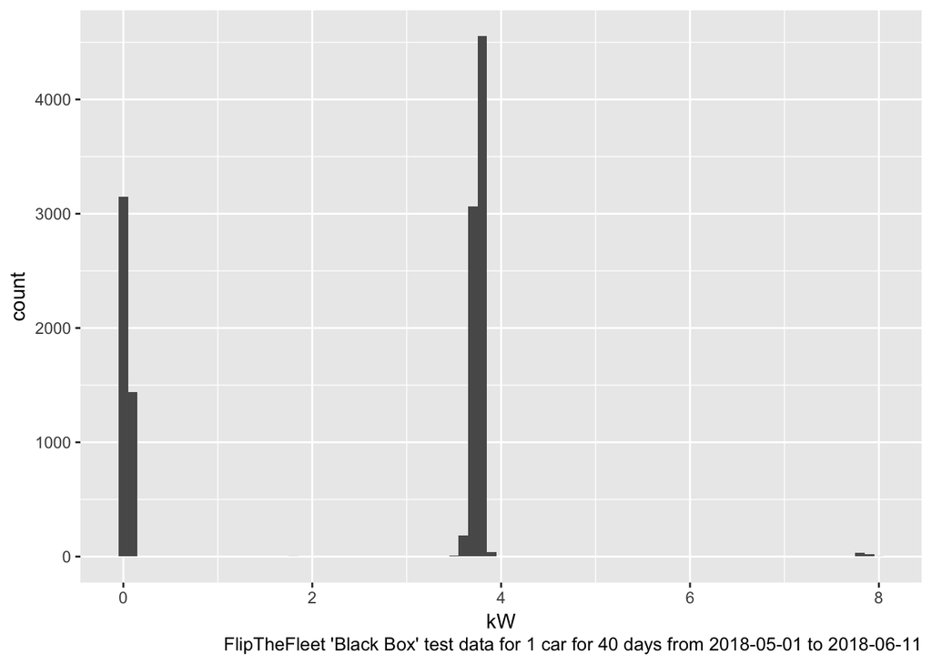

Figure 3.3: Distirbution of derived power demand

The following table sumarises these distributions.

|  | Charger (amps) | Charger (V) | powerW |
| --- | --- | --- | --- |
|  | Min. : 0.00 | Min. : 0.000 | Min. : 0 |
|  | 1st Qu.: 0.00 | 1st Qu.: 1.055 | 1st Qu.: 0 |
|  | Median :15.62 | Median :238.742 | Median :3728 |
|  | Mean :11.77 | Mean :153.032 | Mean :2404 |
|  | 3rd Qu.:15.62 | 3rd Qu.:241.164 | 3rd Qu.:3765 |
|  | Max. :33.44 | Max. :249.445 | Max. :7977 |

> Is the Amp reading of 33 an outlier? If so should we ignore the ~= 8kW values?

# 4 Timing of charging

We assume `powerW` is a good indicator of charging. For now we do not exclude the apparent outlier caused by the few very high Amp values (`Charger (amps)` > 30) but we flag them as potential problems.

The following plot shows mean kW by time of day over the entire test datset of 40 days from 2018-05-01 to 2018-06-11.

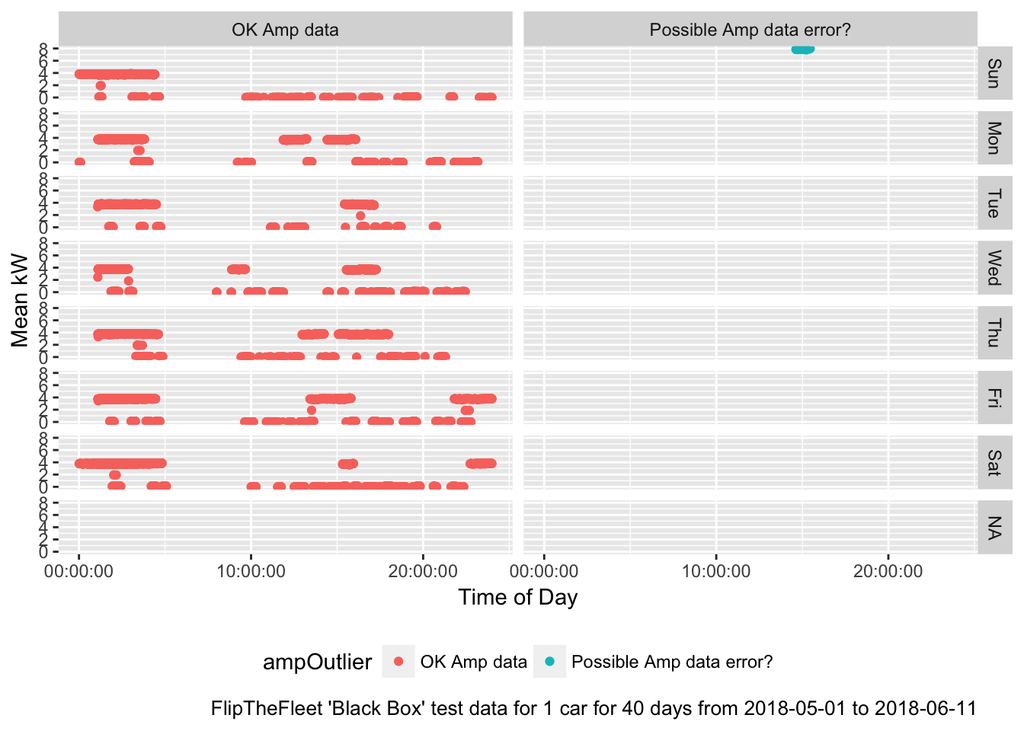

Figure 4.1: Inferred charging times and power draw (all data)

Figure 4.1 seems to show that the very high Amp values occured on one Sunday. We re-draw this plot below (4.2) excluding these outliers and also excluding values of exactly 0 for clarity.

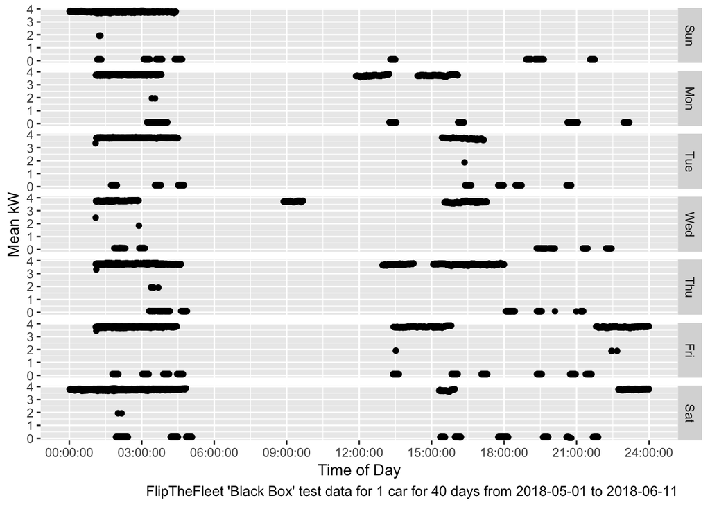

Figure 4.2: Inferred charging times and power draw (outliers and exactly zero values excluded)

We can see that this car appears to be on an overnight charging timer, although we do still see charging scattered through the rest of the day. So where is this charging happening? We need a way to infer when the car is ‘at home’ without being disclosive. Perhaps we could use the modal overnight `Latitude` <-> `Longtidude` as ‘home’?

# 5 Questions to ask

- Data:
  - Do the Amp & Volt distributions look right?
  - Cause of Amp outliers?
- Research:
  - Do all FlipTheFleet EV owners charge like this?
  - Where are the EVs being charged and how can we tell?
  - Does it vary by car/tariff/commute pattern/main use?
  - What other patterns exist and how much within-vehicel and between-vehicle variation is there?

# 6 Runtime

Analysis completed in 10.08 seconds ( 0.17 minutes) using knitr in [RStudio](http://www.rstudio.com) with R version 3.5.0 (2018-04-23) running on x86_64-apple-darwin15.6.0.

# 7 R environment

R packages used:

- base R - for the basics (R Core Team 2016)
- data.table - for fast (big) data handling (Dowle et al. 2015)
- lubridate - date manipulation (Grolemund and Wickham 2011)
- ggplot2 - for slick graphics (Wickham 2009)
- readr - for csv reading/writing (Wickham, Hester, and Francois 2016)
- dplyr - for select and contains (Wickham and Francois 2016)
- knitr - to create this document & neat tables (Xie 2016)
- nzGREENGrid - for local NZ GREEN Grid project utilities

# References

Dowle, M, A Srinivasan, T Short, S Lianoglou with contributions from R Saporta, and E Antonyan. 2015. *Data.table: Extension of Data.frame*. https://CRAN.R-project.org/package=data.table.

Grolemund, Garrett, and Hadley Wickham. 2011. “Dates and Times Made Easy with lubridate.” *Journal of Statistical Software* 40 (3): 1–25. http://www.jstatsoft.org/v40/i03/.

R Core Team. 2016. *R: A Language and Environment for Statistical Computing*. Vienna, Austria: R Foundation for Statistical Computing. https://www.R-project.org/.

Wickham, Hadley. 2009. *Ggplot2: Elegant Graphics for Data Analysis*. Springer-Verlag New York. http://ggplot2.org.

Wickham, Hadley, and Romain Francois. 2016. *Dplyr: A Grammar of Data Manipulation*. https://CRAN.R-project.org/package=dplyr.

Wickham, Hadley, Jim Hester, and Romain Francois. 2016. *Readr: Read Tabular Data*. https://CRAN.R-project.org/package=readr.

Xie, Yihui. 2016. *Knitr: A General-Purpose Package for Dynamic Report Generation in R*. https://CRAN.R-project.org/package=knitr.